# Exercises for the meeting of May 10, 2019

Violeta Sosa

May 09, 2019

## Exercises for the meeting of May 10, 2019

Exercises related to simple features in R (1). Try to upload your answer to the LearnWeb assigned as a .zip file (not a .rar file) containing two files: (i) an R markdown file and (ii) an html file that resulted from knitting the R markdown file. (If this is problematic, use pdf or something else.)

## Exercise 1

Look for a shapefile; download it; import it with `sf::st_read`, and plot it. What does it show?

```r
shapeName <- st_read('depto/depto.shp')
shapeName
```

```
## Simple feature collection with 33 features and 6 fields
## geometry type:  MULTIPOLYGON
## dimension:      XY
## bbox:           xmin: 165298.4 ymin: 20565.69 xmax: 1804280 ymax: 1984871
## epsg (SRID):    NA
## proj4string:    +proj=tmerc +lat_0=4.599047222222222 +lon_0=-74.08091666666667 +k=1 +x_0=1000000 +y_0=1000000 +ellps=intl +units=m +no_defs
## First 10 features:
##    DPTO            NOMBRE_DPT        AREA PERIMETER  HECTARES EFPROM
## 1     5             ANTIOQUIA 63351855547 1963728.8 6335185.6 0.9668
## 2     8             ATLANTICO  3360765350  240936.2  336076.5 0.8347
## 3    11 SANTAFE DE BOGOTA D.C  1650947779  323322.5  165094.8 1.0000
## 4    13               BOLIVAR 26141894528 1309428.0 2614189.5 0.6016
## 5    15                BOYACA 23352582464 1364539.9 2335258.2 0.5466
## 6    17                CALDAS  7558199876  603282.5  755820.0 0.7112
## 7    18               CAQUETA 90180868829 1888506.9 9018086.9 0.6604
## 8    19                 CAUCA 29742787301 1243389.0 2974278.7 0.5588
## 9    20                 CESAR 22973095680 1080343.7 2297309.6 0.5219
## 10   23               CORDOBA 25059485606  814093.4 2505948.6 0.9833
##                          geometry
## 1  MULTIPOLYGON (((754872.1 14...
## 2  MULTIPOLYGON (((913511.2 16...
## 3  MULTIPOLYGON (((1006436 102...
## 4  MULTIPOLYGON (((881889.9 16...
## 5  MULTIPOLYGON (((1206428 126...
## 6  MULTIPOLYGON (((931978.6 11...
## 7  MULTIPOLYGON (((931968.4 76...
## 8  MULTIPOLYGON (((540370.4 82...
## 9  MULTIPOLYGON (((1087325 169...
## 10 MULTIPOLYGON (((809020.2 15...
```

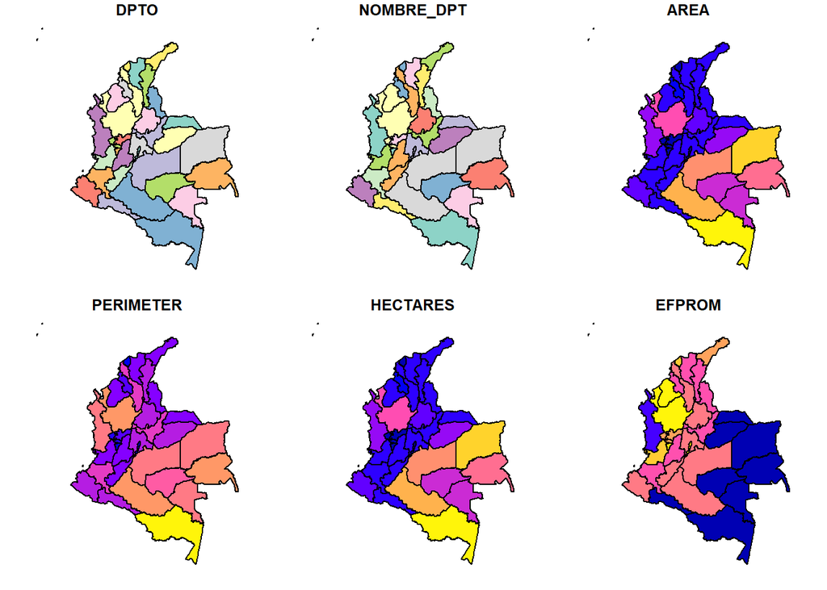

```r
plot(shapeName, main="Colombia shapefile")
```

*The plot shows a map per each one of the attributes defined in the shapefile’s attribute table.*

## Exercise 2

Try plotting one of the attribute variables using a different color scheme

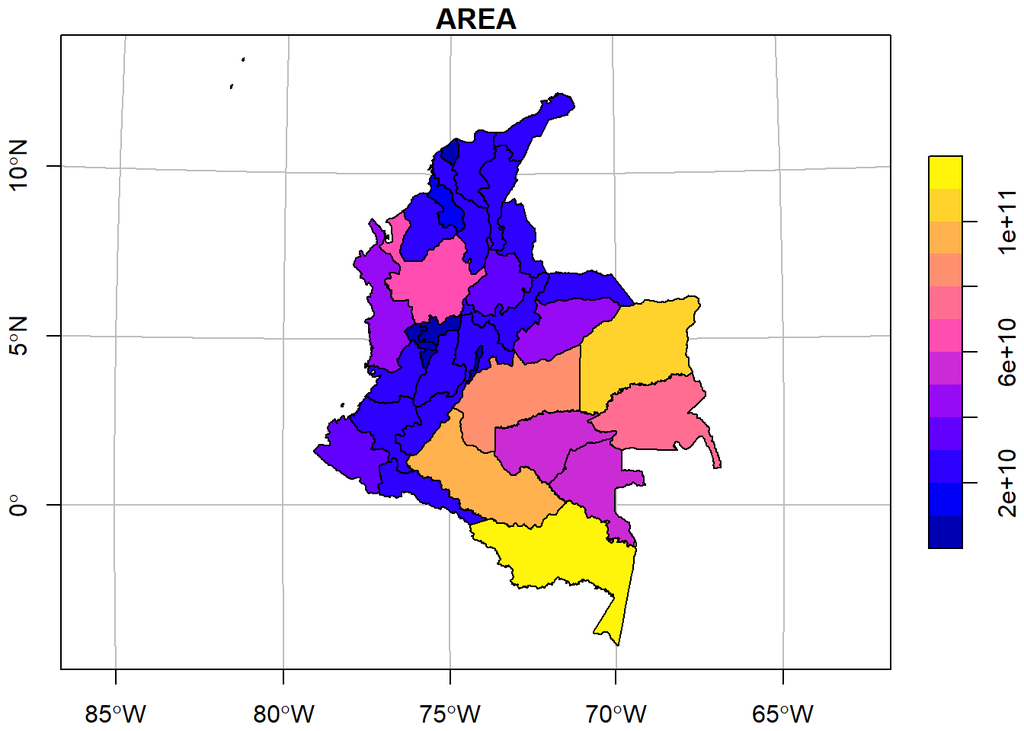

```r
shapeName%>%select(AREA) %>%plot(graticule = TRUE, axes = TRUE)
```

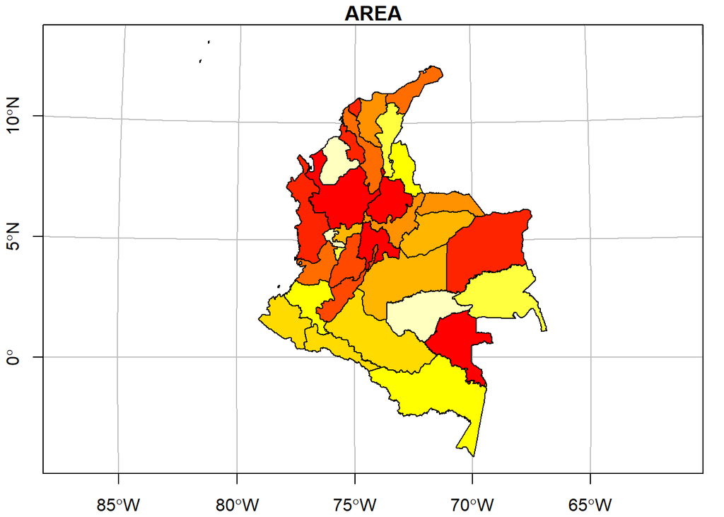

```r
shapeName%>%select(AREA) %>%plot(graticule = TRUE, axes = TRUE, col = heat.colors(10))
```

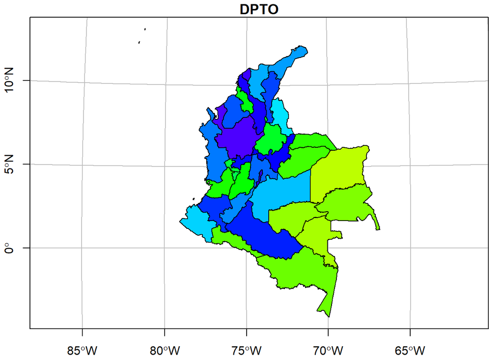

```r
shapeName%>%select(DPTO) %>%plot(graticule = TRUE, axes = TRUE, col = topo.colors(50))
```